# Poisson regression

Novembre 14, 2018

## 1. Insect communities in streams

The stream_composition.csv dataset shows the number of species of five insect orders in 20 streams, as a function of temperature and pH.

```r
stream <- read.csv("stream_composition.csv")
str(stream)
```

```
## 'data.frame':    20 obs. of  8 variables:
##  $ stream     : int  1 2 3 4 5 6 7 8 9 10 ...
##  $ pH         : num  6.8 5.5 6.3 7.3 7.2 7 7 6.1 6.2 7.5 ...
##  $ temperature: num  17.4 17.1 17 16.8 18.9 18.1 16.3 15 15.8 16.8 ...
##  $ mayfly     : int  26 17 7 17 27 28 19 6 9 19 ...
##  $ stonefly   : int  4 1 2 6 3 6 4 4 5 3 ...
##  $ caddisfly  : int  9 23 25 9 16 19 21 21 37 12 ...
##  $ diptera    : int  30 16 10 25 25 30 19 30 26 12 ...
##  $ beetle     : int  3 17 1 1 2 21 13 12 5 3 ...
```

1. Estimate the effect of temperature and pH on the number of stonefly species, with a Poisson regression using the formula `stonefly ~ temperature + pH`. Check if the data is overdispersed and correct your estimates if necessary.
2. What portion of the variance in the number of species is explained by the model?
3. If one of the two variables has a significant effect, interpret the value of the coefficient.
4. Display the observed number of species and the fitted value curves for pH values ranging from 5.5 to 7.5 and for three temperature values: 15, 17 and 19 degrees C.
5. Repeat steps (a) - (d) for a model of the number of mayfly species.
6. What is the average number of mayfly species predicted by the model in (e) for a stream with a temperature of 17 degrees and a pH of 8.5? Is this prediction reliable?

## 2. Salamanders in different forest landscapes

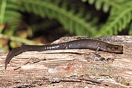

*Photo: Bill Bouton*

The salamander.csv file contains data from Welsh and Lind (1995) on the number of salamanders (`salaman`) of species *Plethodon elongatus* in 47 plots (`site`), as a function of percentage forest cover (`pct_cover`) and forest age.

```r
sal <- read.csv("salamander.csv")
str(sal)
```

```
## 'data.frame':    47 obs. of  4 variables:
##  $ site      : int  1 2 3 4 5 6 7 8 9 10 ...
##  $ salaman   : int  13 11 11 9 8 7 6 6 5 5 ...
##  $ pct_cover : int  85 86 90 88 89 83 83 91 88 90 ...
##  $ forest_age: int  316 88 548 64 43 368 200 71 42 551 ...
```

1. From a Poisson regression, estimate the effect of forest cover on the number of salamanders per plot.
2. Does the `forest_age` predictor improve the predictive power of the model?
3. Produce a graph of the number of salamanders according to forest age and superimpose points representing the fitted values for the model based solely on forest cover. What do you observe?
4. Based on these results, do you think that the forest age directly influences the salamander population? Does it indirectly influence this population?